# Report

Wei-Fu, University of Potsdam, Germany

2024-11-13 06:59

```r
source("lipsum.R")
```

## R Examples

Data loading

```r
options(width=90)
data(iris)
summary(iris)
```

```
##   Sepal.Length    Sepal.Width     Petal.Length    Petal.Width          Species
##  Min.   :4.300   Min.   :2.000   Min.   :1.000   Min.   :0.100   setosa    :50
##  1st Qu.:5.100   1st Qu.:2.800   1st Qu.:1.600   1st Qu.:0.300   versicolor:50
##  Median :5.800   Median :3.000   Median :4.350   Median :1.300   virginica :50
##  Mean   :5.843   Mean   :3.057   Mean   :3.758   Mean   :1.199
##  3rd Qu.:6.400   3rd Qu.:3.300   3rd Qu.:5.100   3rd Qu.:1.800
##  Max.   :7.900   Max.   :4.400   Max.   :6.900   Max.   :2.500
```

Table example:

```r
if (require('knitr',quietly=TRUE)) {
    knitr::kable(head(iris))
} else {
    cat(df2md(head(iris)))
}
```

| Sepal.Length | Sepal.Width | Petal.Length | Petal.Width | Species |
| --- | --- | --- | --- | --- |
| 5.1 | 3.5 | 1.4 | 0.2 | setosa |
| 4.9 | 3.0 | 1.4 | 0.2 | setosa |
| 4.7 | 3.2 | 1.3 | 0.2 | setosa |
| 4.6 | 3.1 | 1.5 | 0.2 | setosa |
| 5.0 | 3.6 | 1.4 | 0.2 | setosa |
| 5.4 | 3.9 | 1.7 | 0.4 | setosa |

Figure example:

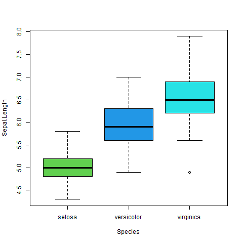

```r
png("iris.png")
with(iris,boxplot(Sepal.Length ~ Species,col=3:5))
dev.off()
```

Inline code example: We have 150 plants in the dataset. That probably needs a fix within the pantcl4r package.

Let’s create an other expression 3+4 is 7.

The following does only work with the pantcl4r package:

We can display flowchart using [GraphViz](https://graphviz.org/docs):

[output not shown]

Or using [Ditaa](https://github.com/stathissideris/ditaa):

[output not shown]

Python example:

```
#!/usr/bin/env python3
import sys
print ("Hello Python 3 World!")
print (sys.version)
```

```python
import sys
print ("Hello Python 3 World!")
print (sys.version)
```

[output not shown]

## Markdown formatting

- list item
- list item

**bold**, **italic**, `typewriter`

> indented
> - indented list
> - indented list

| col1 | col2 | col 3 |
| --- | --- | --- |
| 1 | 2 | 3 |
| 4 | 5 | 6 |

Some more text then here …

## Document processing

This document can be processed to HTML using the packages knitr and markdown or the pantcl4r package:

```
library(knitr);
knitr::knit2html('template.Rmd',output='report.md');
### which should create a file report.html in your current directory
```

Alternatively you can use the package pantcl4r which can be installed like this:

```
install.packages(
    "https://github.com/mittelmark/pantcl4r/releases/download/v0.3.1/pantcl4r_0.3.1.tar.gz",
    repos=NULL);
```

Thereafter you should check the package vignette:

```
library(pantcl4r)
vignette("tutorial",package="pantcl4r")
```

To process a Markdown file for example, with embedded R code, you can do the following:

```
pantcl4r::pantcl("input.Rmd","output.html")
```

If you work on a Unix system we can as well create a Bash script and place it into your personal bin folder.

```
#!/usr/bin/env bash
function rmd2html {
    if [[ -z $1 ]]; then
        echo "Usage: $0 Rmdfile"
    else
        echo "if (require('rmarkdown')) { rmarkdown::render('$1') }
               else (library(pantcl4r)) { pantcl('$1') }
             " | Rscript -
    fi
}
# delegate arguments to the function
rmd2html "$@"
```

If you have the rmarkdown package and pandoc installed you can directly do this from your package:

```
library(rmarkdown);
rmarkdown::render('template.Rmd',html_document())
```

Or using pantcl4r you can do the following:

```
library(pantcl4r)
pantcl4r::pantcl("template.Rmd")
```

My rmarkdown package installation is currently broken more features, more often problems …

## pantcl4r

**Excuse:** Please take into consideration that the [pantcl4r package](https://github.com/mittelmark/pantcl4r) has only one developer, whereas the [rmarkdown package](https://github.com/rstudio/rmarkdown) has 129 developers or the [knitr package](https://github.com/yihui/knitr) has around 170 developers.

Features of the package `pantcl4r`:

- does not depend on other r-packages except on tcltk which is installed by default on Linux and Windows with every R installation
- in contrast for instance rmarkdown depend on 25 other packages
- supports Shell scripts, R, Python, Octave (the open source Matlab) and the Tcl programming languages out of the box
- supports [kroki webservervice](https://kroki.io/)
- can use other tools directly